# Coding Assignment 1 - PSL

Jake Goodman

```r
knitr::opts_chunk$set(echo = TRUE)
set.seed(6379)
```

# Data Generation

### Generate Centers

```r
p = 2;
csize = 10;     # number of centers
sigma = 1;      # sd for generating the centers
m1 = matrix(rnorm(csize*p), csize, p)*sigma +
  cbind( rep(1, csize), rep(0, csize))
m0 = matrix(rnorm(csize*p), csize, p)*sigma +
  cbind( rep(0, csize), rep(1, csize))
```

### Generate Data

```r
sim_params = list(
 csize = 10,      # number of centers
 p = 2,           # dimension
 s = sqrt(1/5),   # standard deviation for generating data
 n = 100,         # training size per class
 N = 5000,        # test size per class
 m0 = m0,         # 10 centers for class 0
 m1 = m1         # 10 centers for class 1
)
generate_sim_data = function(sim_params){
  p = sim_params$p
  s = sim_params$s
  n = sim_params$n
  N = sim_params$N
  m1 = sim_params$m1
  m0 = sim_params$m0
  csize = sim_params$csize

  id1 = sample(1:csize, n, replace = TRUE);
  id0 = sample(1:csize, n, replace = TRUE);
  traindata = matrix(rnorm(2*n*p), 2*n, p)*s + rbind(m1[id1,], m0[id0,])
  Ytrain = factor(c(rep(1,n), rep(0,n)))
  shuffle_row_id = sample(1:n)
  id1 = sample(1:csize, N, replace=TRUE);
  id0 = sample(1:csize, N, replace=TRUE);
  testdata = matrix(rnorm(2*N*p), 2*N, p)*s + rbind(m1[id1,], m0[id0,])
  Ytest = factor(c(rep(1,N), rep(0,N)))

  # Return the training/test data along with labels
  list(
  traindata = traindata,
  Ytrain = Ytrain,
  testdata = testdata,
  Ytest = Ytest
  )
}
```

### Visualize the Data

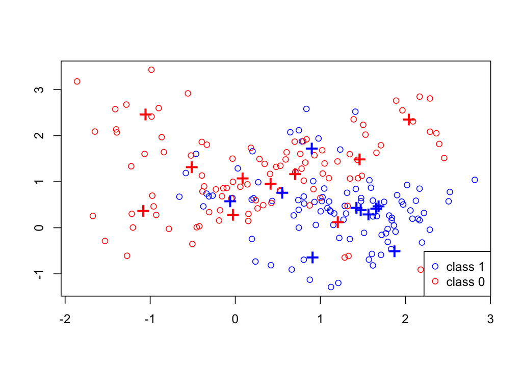

```r
mydata = generate_sim_data(sim_params)
traindata = mydata$train
Ytrain = mydata$Ytrain
testdata = mydata$testdata
Ytest = mydata$Ytest
n = nrow(traindata)

mycol = rep("blue", n)
mycol[Ytrain==0] = "red"
plot(traindata[, 1], traindata[, 2], type = "n", xlab = "", ylab = "")
points(traindata[, 1], traindata[, 2], col = mycol);
points(m1[, 1], m1[, 2], pch = "+", cex = 2, col = "blue");
points(m0[, 1], m0[, 2], pch = "+", cex = 2, col = "red");
legend("bottomright", pch = c(1,1), col = c("blue", "red"),
       legend = c("class 1", "class 0"))
```

# Part I

### Algorithm Prep

Function to calculate Euclidean Distance

```r
euclidean_distance = function(a, b){
  sqrt(sum((a-b)^2))
}
```

KNN function from scratch. Takes in train data, test data, factor of classifications and the k value

In the below function, if there’s multiple points with the same distance, we’ll take the simple approach and just pick the first `k` points

Additionally, if there’s a voting tie (50% probability), we’ll randomly pick the classification.

```r
knn_jg = function(train, test, cl, k){
  predictions = c()
  values = c()
  p_mismatch = 0
  for(i in 1:nrow(testdata)){
    obs = testdata[i:i,]
    dist = apply(traindata, 1, euclidean_distance, obs)
    sort_dist = sort(dist)[1:k]
    neighbors = which(dist %in% sort_dist)

    #Check to see if there are more neighbors than k values
    #if so, just pick the first k neighbors
    if(length(neighbors) != k){
      neighbors = neighbors[1:k]
      print("Length of Neighbors doesn't equal K")

    }
    values[i] = mean(as.numeric(as.character(Ytrain[neighbors])))

    #if there's a voting tie, just pick randomly pick a classification
    if (values[i] == 0.50){
      predictions[i] = sample(0:1, 1)
      p_mismatch = p_mismatch + 1
    }

    else if (values[i] > 0.50){

      predictions[i] = 1
    }
    else{
      predictions[i] = 0
    }

  }

    return(predictions)

}
```

### Results

##### knn value of 1

Values from actual KNN function

```r
library('class')
test.pred = knn(traindata, testdata, Ytrain, k = 1)
table(Ytest, test.pred)
```

```
##      test.pred
## Ytest    0    1
##     0 3441 1559
##     1 1357 3643
```

Values from hand made KNN function

```r
predjg = knn_jg(traindata, testdata, Ytrain, 1)
table(Ytest, predjg)
```

```
##      predjg
## Ytest    0    1
##     0 3441 1559
##     1 1357 3643
```

From the above tables, we can see that the hand-made KNN function exactly matches the packaged KNN function

##### knn value of 3

Values from actual KNN function

```r
test.pred = knn(traindata, testdata, Ytrain, k = 3)
table(Ytest, test.pred)
```

```
##      test.pred
## Ytest    0    1
##     0 3835 1165
##     1 1401 3599
```

Values from hand made KNN function

```r
predjg = knn_jg(traindata, testdata, Ytrain, 3)
table(Ytest, predjg)
```

```
##      predjg
## Ytest    0    1
##     0 3835 1165
##     1 1401 3599
```

From the above tables, we can see that the hand-made KNN function exactly matches the packaged KNN function

##### knn value of 5

Values from actual KNN function

```r
test.pred = knn(traindata, testdata, Ytrain, k = 5)
table(Ytest, test.pred)
```

```
##      test.pred
## Ytest    0    1
##     0 3874 1126
##     1 1287 3713
```

Values from hand made KNN function

```r
predjg = knn_jg(traindata, testdata, Ytrain, 5)
table(Ytest, predjg)
```

```
##      predjg
## Ytest    0    1
##     0 3874 1126
##     1 1287 3713
```

From the above tables, we can see that the hand-made KNN function exactly matches the packaged KNN function

# Part II

### Linear Regression Model

Function for Linear Regression Model

```r
fit_lr_model = function(sim_data, verbose=FALSE) {

  # change Y from factor to numeric
  sim_data$Ytrain = as.numeric(sim_data$Ytrain) - 1
  sim_data$Ytest = as.numeric(sim_data$Ytest) - 1

  # fit a linear regression model
  model = lm(
    sim_data$Ytrain ~ .,
    as.data.frame(sim_data$traindata)
  )
  if (verbose) {
    print(summary(model))
  }

  decision_thresh = 0.5
  train_pred = as.numeric(model$fitted.values > decision_thresh)

  test_yhat = predict(
    model,
    newdata=as.data.frame(sim_data$testdata)
  )
  test_pred = as.numeric(test_yhat > decision_thresh)

  # return the mean classification errors on training/test sets
  list(
    train_error = mean(sim_data$Ytrain  != train_pred),
    test_error = mean(sim_data$Ytest  != test_pred)
  )
}
```

Finding train and test error for Linear Model

```r
lr_train_error = c()
lr_test_error = c()

for(i in 1:50){
  sim_data = generate_sim_data(sim_params)
  lr_output = fit_lr_model(sim_data)
  lr_train_error[i] = lr_output$train_error
  lr_test_error[i] = lr_output$test_error
}
```

### Quadratic Regresion Model

Function for Quadratic Regression Model

```r
fit_qr_model = function(sim_data, verbose=FALSE) {

  # change Y from factor to numeric
  sim_data$Ytrain = as.numeric(sim_data$Ytrain) - 1
  sim_data$Ytest = as.numeric(sim_data$Ytest) - 1

  # fit a quadratic regression model
  model = lm(
    sim_data$Ytrain ~
      V1 + V2 + I(V1^2) + I(V2^2) + V1:V2,
    as.data.frame(sim_data$traindata)
  )
  if (verbose) {
    print(summary(model))
  }

  decision_thresh = 0.5
  train_pred = as.numeric(model$fitted.values > decision_thresh)

  test_yhat = predict(
    model,
    newdata=as.data.frame(sim_data$testdata)
  )
  test_pred = as.numeric(test_yhat > decision_thresh)

  # return the mean classification errors on training/test sets
  list(
    train_error = mean(sim_data$Ytrain  != train_pred),
    test_error = mean(sim_data$Ytest  != test_pred)
  )
}
```

Finding train and test error for Quadratic Model

```r
qr_train_error = c()
qr_test_error = c()

for(i in 1:50){
  sim_data = generate_sim_data(sim_params)
  qr_output = fit_qr_model(sim_data)
  qr_train_error[i] = qr_output$train_error
  qr_test_error[i] = qr_output$test_error
}
```

### CV-KNN

cvKNNAveErrorRate Function Definition

```r
cvKNNAveErrorRate = function(K, traindata, Ytrain, foldNum ){

  n = nrow(traindata)
  foldSize = floor(n/foldNum)
  error = 0
  myIndex = sample(1 : n)
  for(runId in 1:foldNum){
    testSetIndex = ((runId-1)*foldSize + 1):(ifelse(runId == foldNum, n, runId*foldSize))
    testSetIndex = myIndex[testSetIndex]
    trainX = traindata[-testSetIndex, ]
    trainY = Ytrain[-testSetIndex]
    testX = traindata[testSetIndex, ]
    testY = Ytrain[testSetIndex]
    predictY = knn(trainX, testX, trainY, K)
    error = error + sum(predictY != testY)
  }
  error = error / n
  error
}
```

cvKNN Function Definition

```r
cvKNN = function(sim_data, foldNum) {
  traindata = sim_data$traindata
  Ytrain = sim_data$Ytrain
  n = nrow(traindata)
  foldSize = floor(n/foldNum)
  KVector = seq(1, (nrow(traindata) - foldSize), 1)
  cvErrorRates = sapply(KVector, cvKNNAveErrorRate, traindata, Ytrain, foldNum)
  result = list()
  result$bestK = max(KVector[cvErrorRates == min(cvErrorRates)])
  result$cvError = cvErrorRates[KVector == result$bestK]
  result

}
```

Find CVV-KNN Errors

```r
opt_k = c()
knn_train_error = c()
knn_test_error = c()

for(i in 1:50){
  sim_data = generate_sim_data(sim_params)

  opt_k[i] = cvKNN(sim_data, 10)[[1]]
  predictTest = knn(sim_data$traindata, sim_data$testdata, sim_data$Ytrain, opt_k[i])
  knn_test_error[i] = mean(predictTest != sim_data$Ytest)

  predictTrain = knn(sim_data$traindata, sim_data$traindata, sim_data$Ytrain, opt_k[i])
  knn_train_error[i] = mean(predictTrain != sim_data$Ytrain)

}
```

### Bayes Formula

Function for Mixnorm Ratio

```r
mixnorm = function(x, centers0, centers1, s){
  ## return the density ratio for a point x, where each
  ## density is a mixture of normal with multiple components
  d1 = sum(exp(-apply((t(centers1) - x)^2, 2, sum) / (2 * s^2)))
  d0 = sum(exp(-apply((t(centers0) - x)^2, 2, sum) / (2 * s^2)))

  return (d1 / d0)
}
```

Calculating Errors for Bayes Formula

```r
bayes_train_error = c()
bayes_test_error = c()

#
for(i in 1:50){
  sim_data = generate_sim_data(sim_params)
  train_prob = as.numeric(apply(sim_data$traindata, 1, mixnorm, sim_params$m0, sim_params$m1, s = sim_params$s) > 1)
  bayes_train_error[i] = mean(train_prob != sim_data$Ytrain)

  test_prob = as.numeric(apply(sim_data$testdata, 1, mixnorm, sim_params$m0, sim_params$m1, s = sim_params$s) > 1)
  bayes_test_error[i] = mean(test_prob != sim_data$Ytest)
}
```

### Chosen K Values

```r
paste("Mean of chosen K values: ", mean(opt_k))
```

```
## [1] "Mean of chosen K values:  21.84"
```

```r
paste("Standard Deviation of chosen K values: ", round(sd(opt_k),2))
```

```
## [1] "Standard Deviation of chosen K values:  13.7"
```

### Error Rate Boxplot

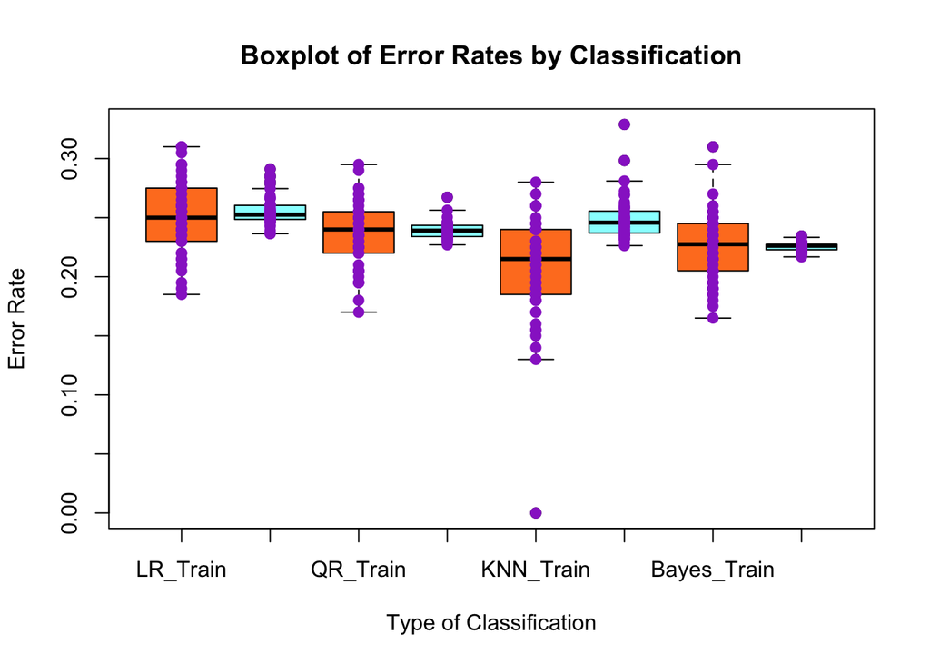

```r
library(ggplot2)

error_df = data.frame(
  "LR_Train" = lr_train_error
  ,"LR_Test" = lr_test_error
  ,"QR_Train" = qr_train_error
  ,"QR_Test" = qr_test_error
  ,"KNN_Train" = knn_train_error
  ,"KNN_Test" = knn_test_error
  ,"Bayes_Train" = bayes_train_error
  ,"Bayes_Test" = bayes_test_error
)

boxplot(error_df, main = "Boxplot of Error Rates by Classification",xlab = "Type of Classification"
        , ylab = "Error Rate", col = c("chocolate1", "darkslategray1"))
stripchart(error_df, add = TRUE, vertical = TRUE, jitter = 0.20, pch = 19, col = "darkorchid")
```